# Maine Coastal Current Index

Matt Dzaugis

2022-01-26

## Gulf of Maine Coastal Current

The Gulf of Maine Coastal Current is a semi-continuous current that extends from southern Nova Scotia to Cap Cod, MA. The Maine Coastal Current may extend the entire length of the coast of Maine and other times breaks off into two (or more) branches. The branches often diverge at Penobscot Bay, forming the Eastern Maine Coastal Current (EMCC) and Western Maine Coastal Current (WMCC). It is hypothesized that the degree of continuity between the continuity between the EMCC and WMCC has implications for phytoplankton, zooplankton, and larval lobster transport (Pettigrew et al. 1994, McManus et al 2014, Townsend et al 2004, Xue et al 2008). Using a principal components analysis of surface current speed for the eastward (u) direction of an area just offshore of Penobscot Bay, the Maine Coastal Current can be decomposed into the Maine Coastal Current Index that captures the connectivity between the EMCC and WMCC. In this analysis, the first principal component, which capture 52.5% of the variability in the dataset, provides an index of connectivity. The second principal component, which captures 15.3% of the variability, is related to vorticity.

## Methods

### Location of Maine Coastal Current Turnoff

An area that extends from Popham Beach in the west to Jonesport in the east and offshore out to Jordan Basin was identified as the area that encompass the most eastern and western locations where the MCC turns off shore (figure 1). This area was purposefully chosen to exclude most of the coastal islands, as the highly variable currents around the islands led to some spurious results. Water velocity and direction data from this area were used to calculate the Maine Coastal Current Index.

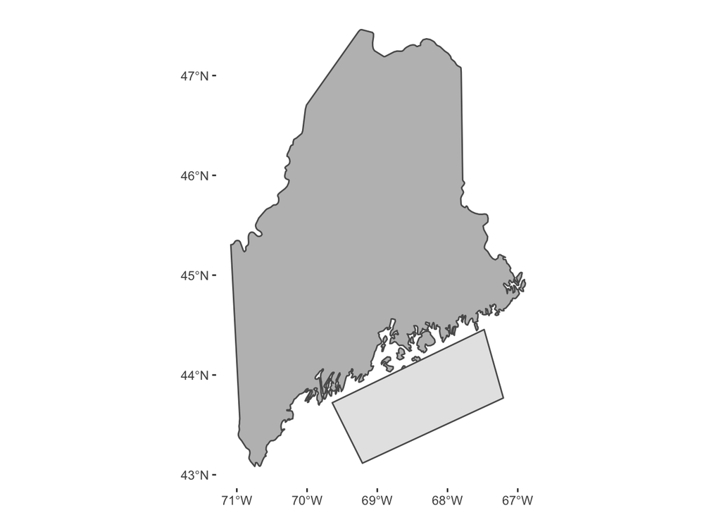

Location of the area used to calculate the Maine Coastal Current Index

### Principal Components Analysis

Data from Finite Volume Community Ocean Model (FVCOM) were used for the eastward water velocities from the years 1980-2016. FVCOM is an unstructured grid and as such contains cells of different sizes. The data were transformed to a regular 1/10 degree grid for this analysis. A PCA was used to determine the leading modes of variability of the water current data. Each eastward vector for each grid cell were used as the variables and each Date (month and year) were the observations.

### Results

Another way to check the relationship between the variables and PC1 and PC2 is to plot the most diverging examples of each PC. Isolating those variables (dates) we find that positive PC1 indicates southwestern water movement, and negative PC1 indicates northeasterly water movement. PC2 is a little more difficult to grasp, but it seems represents the uniformity of water direction, where a negative PC2 indicates higher vorticity where as a positive PC2 indicates water more uniform water movement. Use this RShiny app to compare the see how the two PCs change the shape of the currents https://mdzaugis.shinyapps.io/Maine_Coastal_Current/ and figure 6 shows an example of a low vs high PC1.

When using PC1 as the coastal current index, positive values indicate greater connectivity between the EMCC and WMCC and negative values indicate lower connectivity and offshore movement.

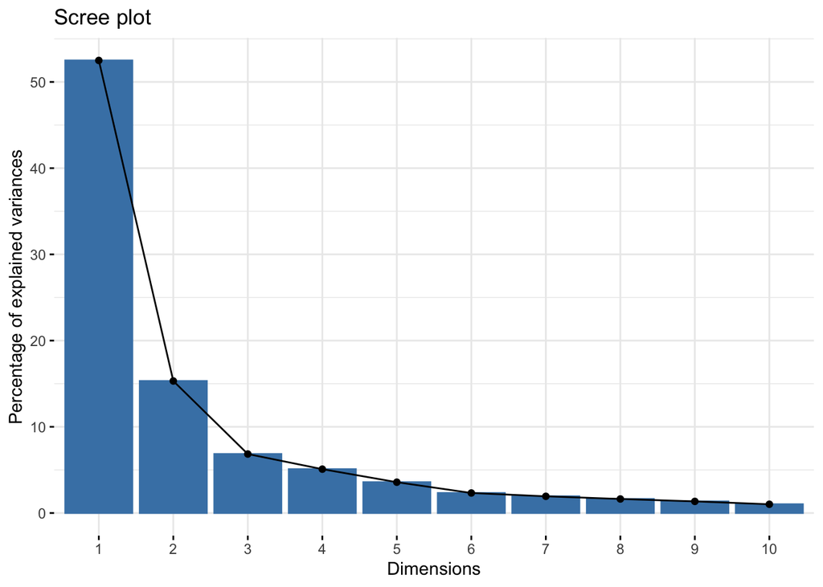

Figure 2. Scree plot of the Maine Coastal Current PCA

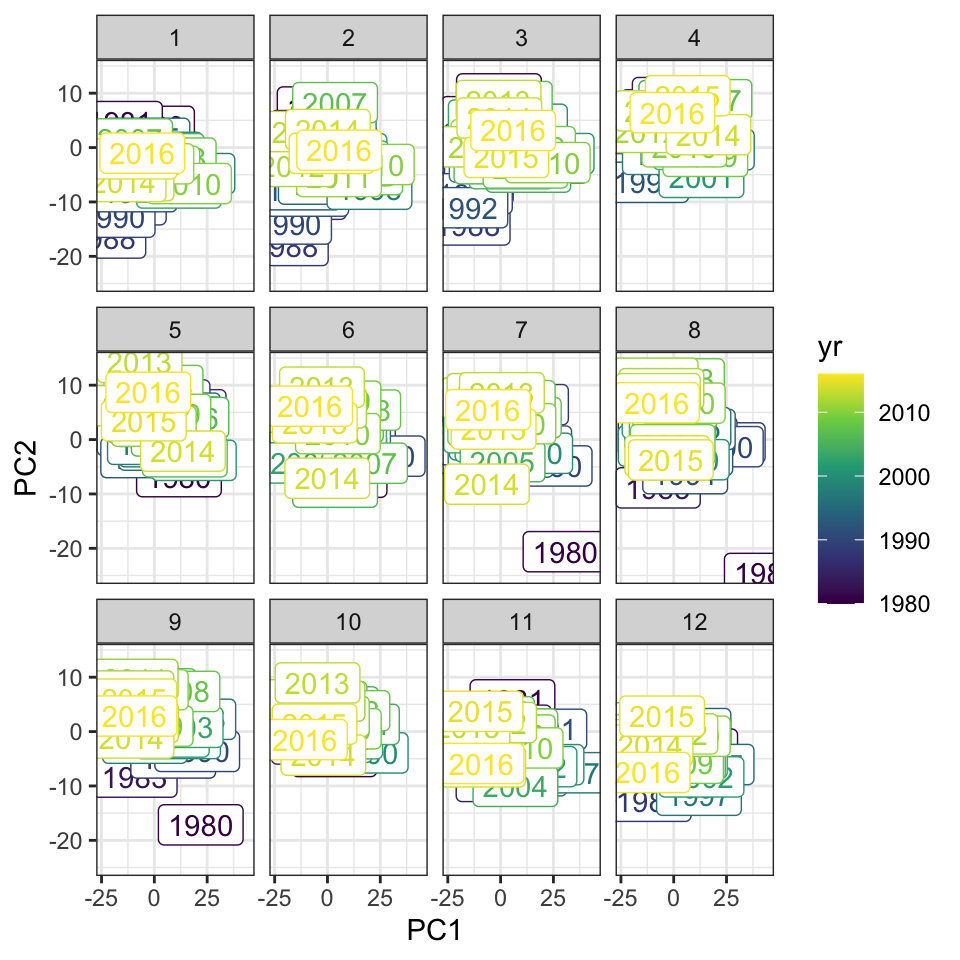

Figure 3. Plot of the observations by month.

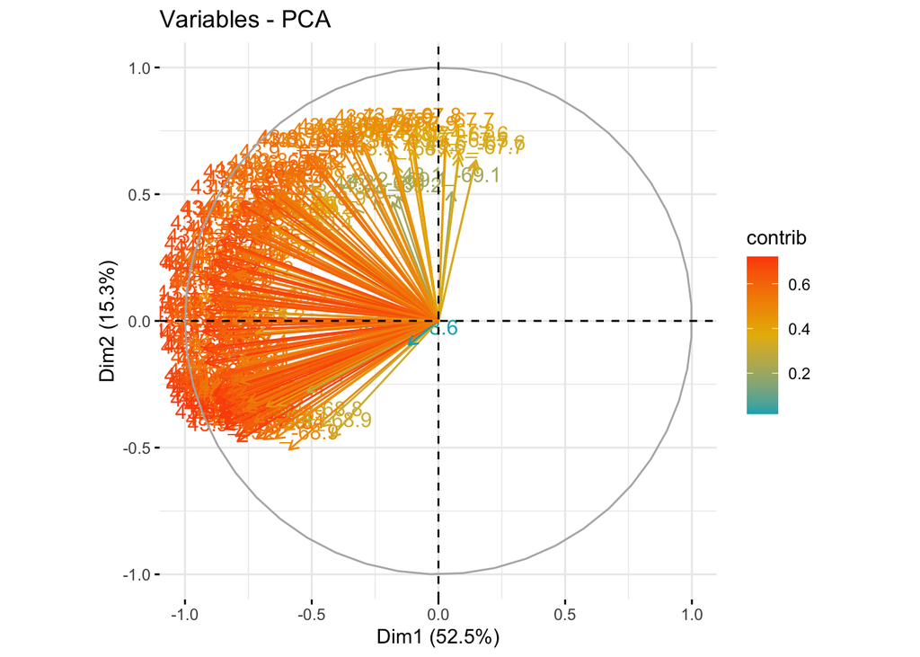

Figure 4. Loadings of the variables

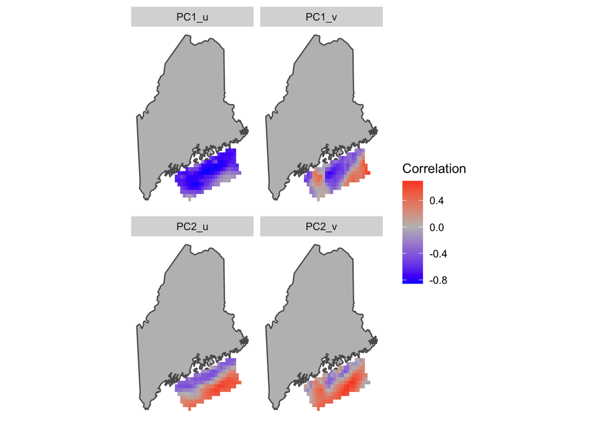

Figure 5. Correlation between PC1 and eastward water velocity (top left, ‘PC1_u’), PC1 and northward water velocity (top right, ‘PC1_v’), PC2 and eastward water velocity (bottom left, ‘PC2_u’), and PC2 and northward water velocity (bottom right, ‘PC2_v’)

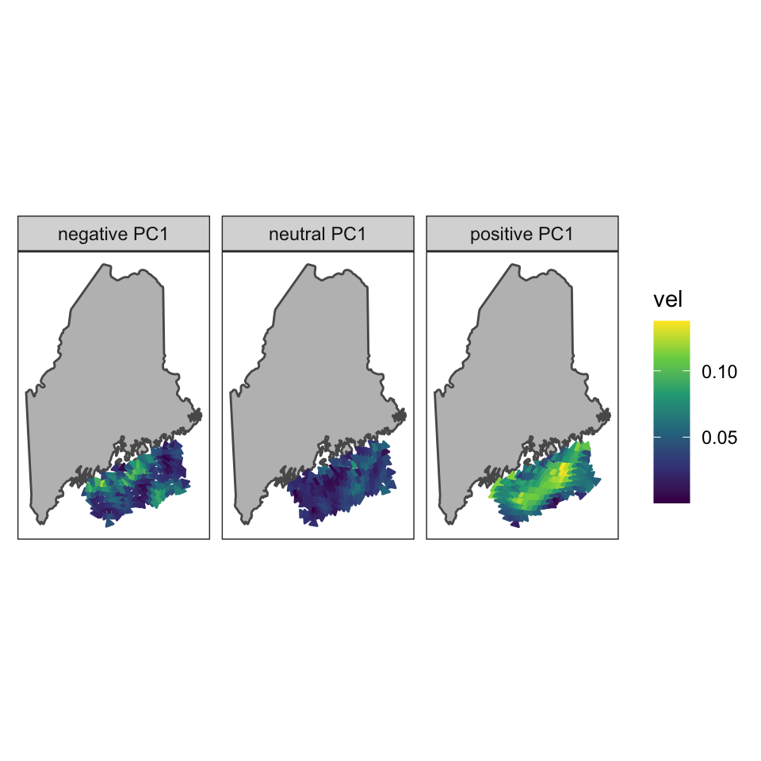

```
## [1] "2008-08-01" "2014-08-01" "1991-08-01"
```

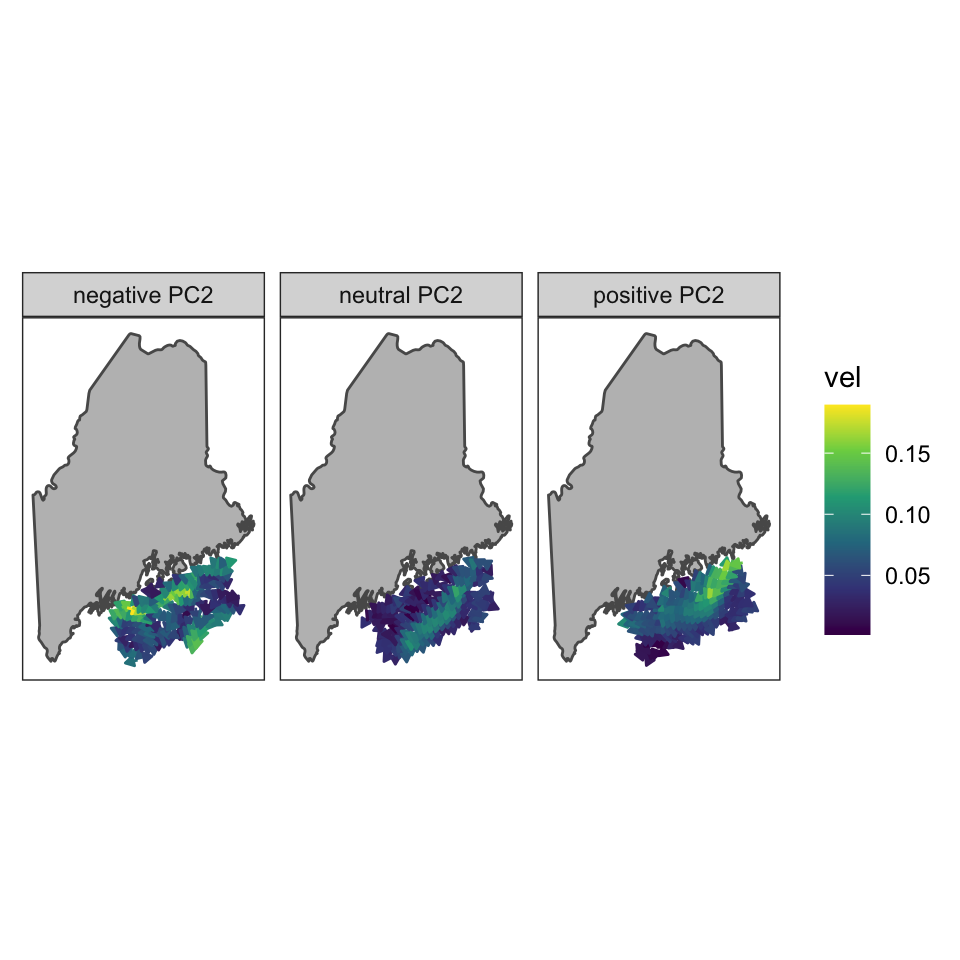

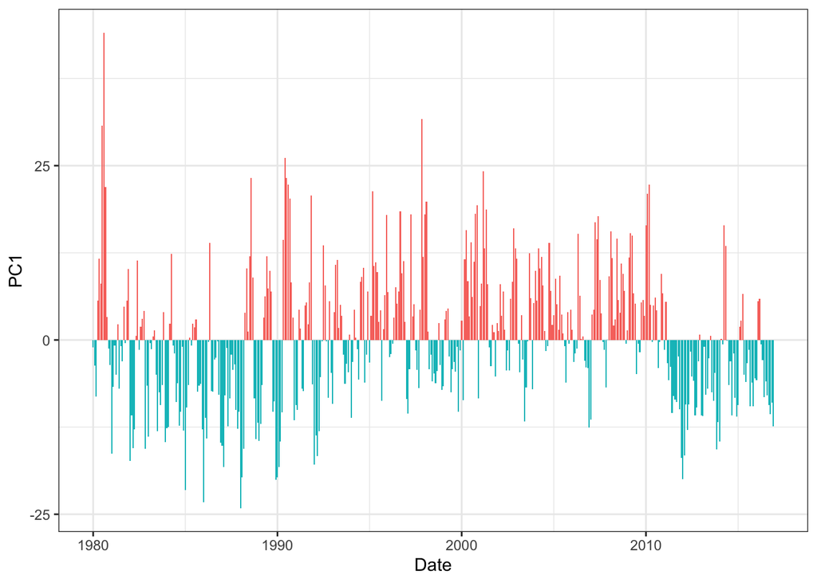

Figure 7. Monthly time series of PC1 or the Maine Coastal Current Index. Negative values indicate a break in the current and positive values indicate a continuous current.

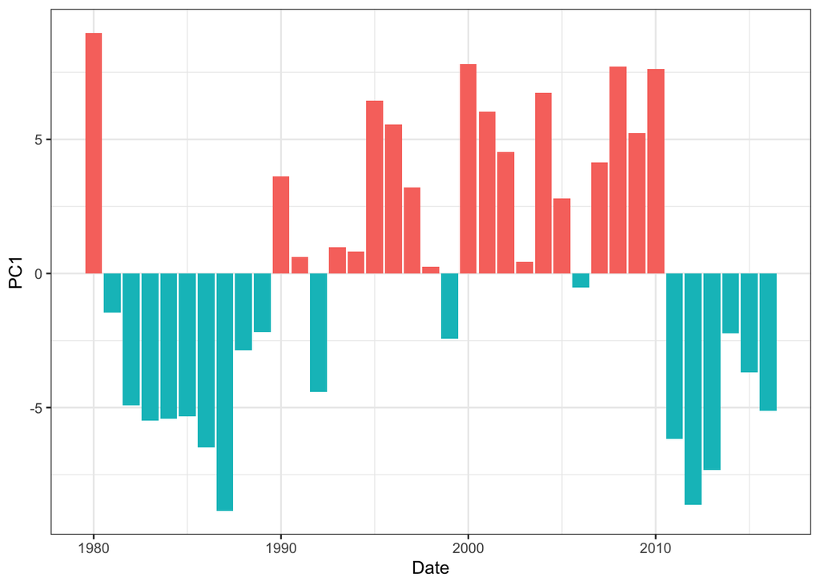

Figure 8. Yearly time series of PC1 or the Maine Coastal Current Index. Negative values indicate a break in the current and positive values indicate a continuous current.

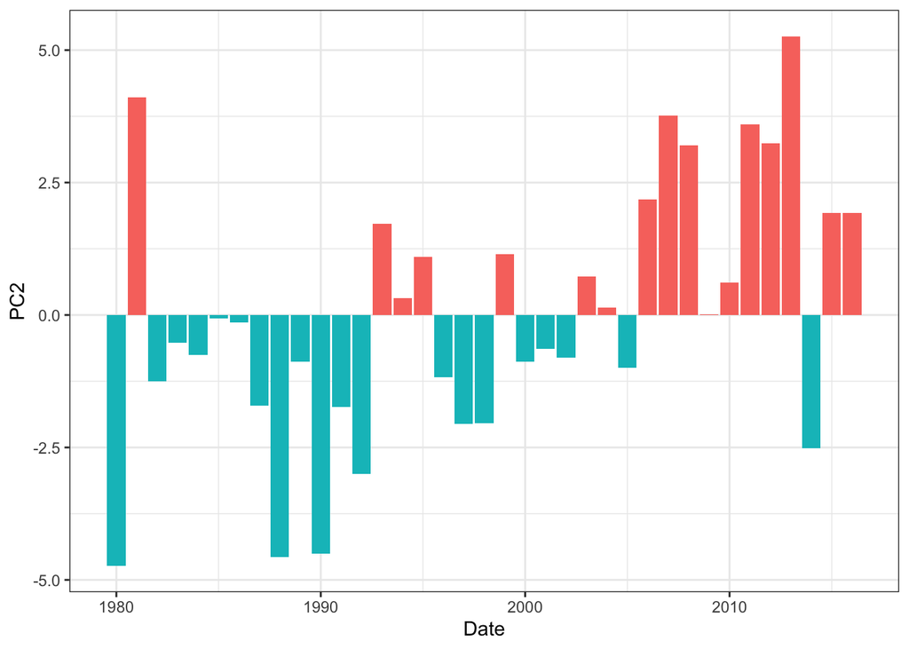

Figure 9. Yearly time series of PC2 or the Maine Coastal Current Index. Negative PC2 indicates higher vorticity where as a positive PC2 indicates water more uniform water movement.

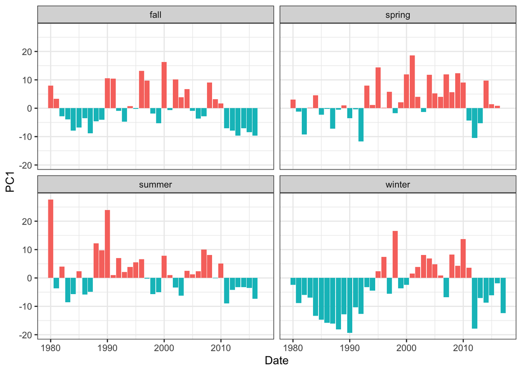

Figure 10. Season-year Time series of PC1 or the Maine Coastal Current Index. Negative values indicate a break in the current and positive values indicate a continuous current.